# Handling Missing Values

Machine Learning

Feature Engineering

Author

Angel Feliz

Published

November 9, 2023

## 1 Introduction

If you are working with real data, it’s normal to find missing values, so it’s very important to understand how to manage them correctly. In `R`, **the default for many functions is to remove missing values** to create plots or train machine learning models, but that can be very dangerous as we are **adding bias** to our analysis that could compromise our final conclusions.

But removing values could be a good option if we meet the following statements:

- Only 5% of your dataset’s rows present missing values.
- All the values have the same probability to be missing. That’s when we say that they are **missing completely at random (MCAR)**.

Otherwise, the **best** way to handle missing values is to **impute values** based on general patterns found in the data. If we cannot find patterns in the current data, we will need to find more data until finding a valid pattern to impute the values.

## 2 Imputation practical example

Let’s assume that all the **predictors** for a machine learning model are stored in the `datasets::airquality` data frame, which has some missing values, so we need to explore and decide what to do in this case.

To perform all the tasks needed to solve the missing values problems in our dataset, we will load the following packages:

```r
# For modeling and statistical analysis
library(tidymodels)

# For modeling lasso or elastic-net regression
library(glmnet)

# For exploring missing values
library(naniar)
library(mice)
```

### 2.1 Confirming if values are MCAR

Based on the next test, we can reject the null hypothesis and conclude that the missing values **aren’t completely at random**, so we will need to impute the missing values.

```r
mcar_test(airquality)
```

```
# A tibble: 1 × 4
  statistic    df p.value missing.patterns
      <dbl> <dbl>   <dbl>            <int>
1      35.1    14 0.00142                4
```

### 2.2 Explore missing values patterns

Once we know that we need to impute values, it’s important to know that the column with more missing values is the `Ozone` with 37 values to impute, which we can divide between the ones that can use the rest of the features (35 rows) and the ones that can use all the columns except the `Solar.R` as they are missing (2 rows).

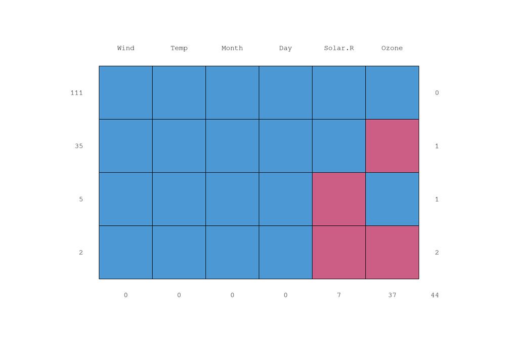

```r
airquality |>
  md.pattern() |>
  invisible()
```

### 2.3 Imputing Ozone values

#### 2.3.1 Exploring missing values

In the next plot we can see how the missing `Ozone` values are spread across a wide range of values, so we wouldn’t be able to find big differences between the means of columns with or without missing `Ozone` values.

As we are plotting all variables against the target variable, it’s easy to see that the `Temp`, `Wind` and `Solar.R` present a not linear relation with `Ozone` and we cannot see a clear pattern for `Day` and `Month`.

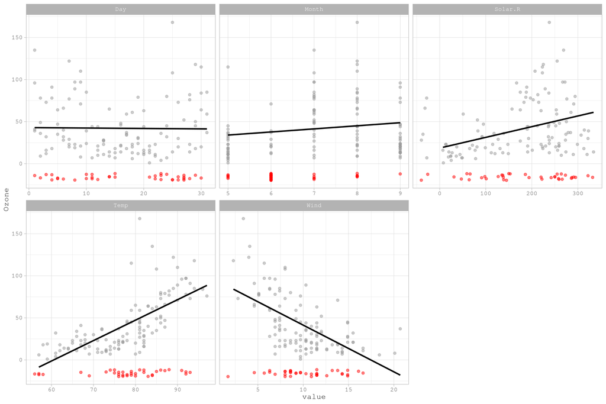

```r
airquality |>
  pivot_longer(cols = -Ozone) |>
  ggplot(aes(value, Ozone))+
  geom_miss_point(aes(color = is.na(Ozone)),
                  alpha = 0.5,
                  show.legend = FALSE)+
  geom_smooth(method = "lm",
              se = FALSE,
              color = "black")+
  scale_color_manual(values = c("TRUE" = "red",
                                "FALSE" = "gray60"))+
  facet_wrap(~name, scales = "free_x")+
  theme_light()
```

*Based on this result, we know it’s necessary to train a model able to catch the non-linear patterns and omit the *Day* and *Month* as they don’t show any relation with Ozone.*

#### 2.3.2 Training the model to impute

As we need to create 2 very similar models (one using the `Solar.R` column and other without it) it’s better to create a function.

```r
fit_tuned_regression_model <- function(df,
                                       model_to_tune,
                                       model_grid,
                                       formula,
                                       step_fun,
                                       seed = 1234){

  # Defining empty model workflow
  y_wf <-
    recipe(formula, data = df) |>
    step_fun() |>
    workflow(model_to_tune)

  # Defining re-samples based on seed
  set.seed(seed)
  y_resamples <- mc_cv(df, times = 30)
  set.seed(NULL)

  # Fitting re-sample for each grid level
  y_tuned <- tune_grid(
    y_wf,
    resamples = y_resamples,
    grid = model_grid,
    metrics = metric_set(yardstick::rsq)
  )

  # Selecting the best model
  y_trained_model <-
    finalize_workflow(y_wf,
                      select_best(y_tuned)) |>
    fit(df)

  # Presenting results
  results <- list("fit" = y_trained_model,
                  "best_fit" = show_best(y_tuned))

  print(results$best_fit)

  return(results)

}
```

Then we need to define common inputs for both models.

```r
GlmModel <- linear_reg(
  engine = "glmnet",
  penalty = tune(),
  mixture = tune()
)

GlmGrid <- grid_regular(
  penalty(),
  mixture(),
  levels = 10
)

ozone_steps <- function(recipe){

  recipe |>
  step_poly(all_numeric_predictors(),
            degree = 2) |>
    step_interact(terms = ~(. -Ozone)^2) |>
    step_zv(all_numeric_predictors()) |>
    step_scale(all_numeric_predictors())

}
```

Now we can fit each model.

```r
OzoneSolarGlmFitted <- fit_tuned_regression_model(
  df = na.omit(airquality),
  model_to_tune = GlmModel,
  model_grid = GlmGrid,
  formula = as.formula("Ozone ~ Solar.R + Temp + Wind"),
  step_fun = ozone_steps,
  seed = 5050
)
```

```
# A tibble: 5 × 8
        penalty mixture .metric .estimator  mean     n std_err .config
          <dbl>   <dbl> <chr>   <chr>      <dbl> <int>   <dbl> <chr>
1 1               1     rsq     standard   0.721    30  0.0159 Preprocessor1_Mo…
2 1               0.889 rsq     standard   0.721    30  0.0157 Preprocessor1_Mo…
3 1               0.778 rsq     standard   0.720    30  0.0156 Preprocessor1_Mo…
4 0.0000000001    0     rsq     standard   0.718    30  0.0165 Preprocessor1_Mo…
5 0.00000000129   0     rsq     standard   0.718    30  0.0165 Preprocessor1_Mo…
```

```r
OzoneNotSolarGlmFitted <- airquality |>
  select(-Solar.R) |>
  na.omit() |>
  fit_tuned_regression_model(model_to_tune = GlmModel,
                         model_grid = GlmGrid,
                         formula = as.formula("Ozone ~ Temp + Wind"),
                         step_fun = ozone_steps,
                         seed = 4518)
```

```
# A tibble: 5 × 8
        penalty mixture .metric .estimator  mean     n std_err .config
          <dbl>   <dbl> <chr>   <chr>      <dbl> <int>   <dbl> <chr>
1 0.0000000001        0 rsq     standard   0.654    30  0.0120 Preprocessor1_Mo…
2 0.00000000129       0 rsq     standard   0.654    30  0.0120 Preprocessor1_Mo…
3 0.0000000167        0 rsq     standard   0.654    30  0.0120 Preprocessor1_Mo…
4 0.000000215         0 rsq     standard   0.654    30  0.0120 Preprocessor1_Mo…
5 0.00000278          0 rsq     standard   0.654    30  0.0120 Preprocessor1_Mo…
```

#### 2.3.3 Impute missing values

Once we have both models, we can impute the `Ozone` values, but let’s also create a function to perform this task as we will need to repeat the process very time we need to predict a new value.

```r
impute_ozone <- function(df,
                         solar_model,
                         no_solar_model){

  mutate(df,
         Ozone_NA = is.na(Ozone),
         Ozone = case_when(
           !is.na(Ozone) ~ Ozone,
           !is.na(Solar.R)~
             predict(solar_model, new_data = df)$.pred,
           TRUE ~
             predict(no_solar_model, new_data = df)$.pred)
  )
}


AirOzoneImputed <- impute_ozone(
  airquality,
  solar_model = OzoneSolarGlmFitted$fit,
  no_solar_model = OzoneNotSolarGlmFitted$fit
)
```

By plotting the imputed `Ozone` values can see that the values follow the patterns present in the non-missing values.

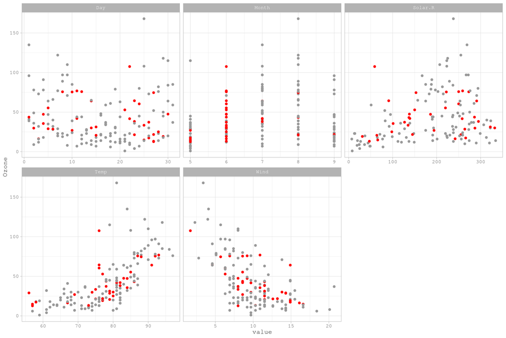

```r
AirOzoneImputed |>
  pivot_longer(cols = -c(Ozone, Ozone_NA)) |>
  na.omit() |>
  ggplot(aes(value, Ozone, color = Ozone_NA))+
  geom_point(show.legend = FALSE)+
  scale_color_manual(values = c("TRUE" = "red",
                                "FALSE" = "grey60"))+
  facet_wrap(~name, scales = "free_x")+
  theme_light()
```

### 2.4 Fixing Solar.R values

Once we don’t have any missing value in the `Ozone` column we can explore the remaining 7 missing values in the `Solar.R` column.

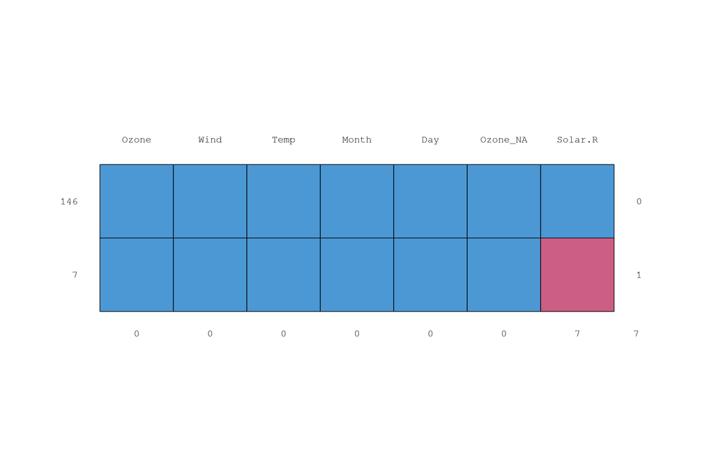

```r
AirOzoneImputed |>
  md.pattern() |>
  invisible()
```

Now the missing values represent only 5% of the rows.

```r
nrow(na.omit(AirOzoneImputed)) / nrow(AirOzoneImputed) * 100
```

```
[1] 95.42484
```

And we don’t have enough data to reject the null hypothesis, and we can not affirm that the missing values are not missing completely at random.

```r
mcar_test(AirOzoneImputed)
```

```
# A tibble: 1 × 4
  statistic    df p.value missing.patterns
      <dbl> <dbl>   <dbl>            <int>
1      10.3     6   0.114                2
```

So we can remove the remaining missing values.

```r
AirqualityImputed <- na.omit(AirOzoneImputed)

head(AirqualityImputed)
```

```
  Ozone Solar.R Wind Temp Month Day Ozone_NA
1    41     190  7.4   67     5   1    FALSE
2    36     118  8.0   72     5   2    FALSE
3    12     149 12.6   74     5   3    FALSE
4    18     313 11.5   62     5   4    FALSE
7    23     299  8.6   65     5   7    FALSE
8    19      99 13.8   59     5   8    FALSE
```

## 3 Final thoughts

I hope this blog can help to improve your ability to handle missing values without compromising your results.

Don’t forget to explore well your columns as missing values are usually encoded with *0* or *99*.